# Homework

```r
library(tidyverse)
library(janitor)
library(GGally)
library(ggfortify)
library(mosaic)
```

1. Load the `housing_prices.csv` data set and undertake an initial exploration of the data. You will find details on the data set on the relevant [Kaggle page](https://www.kaggle.com/camnugent/california-housing-prices)

[output not shown]

```r
head(price)

summary(price)
```

```
   longitude         latitude     housing_median_age  total_rooms
 Min.   :-124.3   Min.   :32.54   Min.   : 1.00      Min.   :    2
 1st Qu.:-121.8   1st Qu.:33.93   1st Qu.:18.00      1st Qu.: 1438
 Median :-118.5   Median :34.27   Median :28.00      Median : 2111
 Mean   :-119.6   Mean   :35.65   Mean   :28.39      Mean   : 2620
 3rd Qu.:-118.0   3rd Qu.:37.73   3rd Qu.:37.00      3rd Qu.: 3120
 Max.   :-114.3   Max.   :41.95   Max.   :52.00      Max.   :39320

 total_bedrooms     population      households     median_income
 Min.   :   2.0   Min.   :    3   Min.   :   2.0   Min.   : 0.4999
 1st Qu.: 297.0   1st Qu.:  796   1st Qu.: 282.0   1st Qu.: 2.5268
 Median : 436.0   Median : 1179   Median : 411.0   Median : 3.4500
 Mean   : 539.6   Mean   : 1441   Mean   : 501.2   Mean   : 3.6767
 3rd Qu.: 648.0   3rd Qu.: 1746   3rd Qu.: 606.0   3rd Qu.: 4.5826
 Max.   :6445.0   Max.   :35682   Max.   :6082.0   Max.   :15.0001
 NA's   :200
 median_house_value ocean_proximity
 Min.   : 14999     Length:19675
 1st Qu.:116600     Class :character
 Median :173800     Mode  :character
 Mean   :192478
 3rd Qu.:248200
 Max.   :500000
```

2. We expect the `total_rooms` of houses to be strongly correlated with `total_bedrooms`. Use `ggpairs()` to investigate correlations between these two variables.

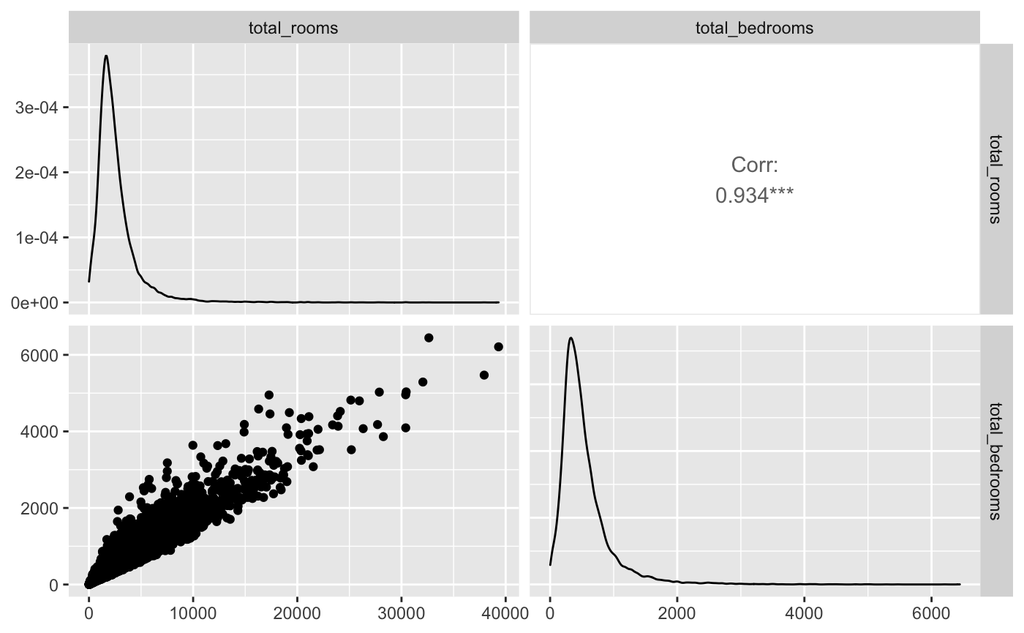

3. So, we do find significant correlations. Let’s drop `total_bedrooms` from the dataset, and use only `total_rooms` going forward.

| longitude | latitude | housing_median_age | total_rooms | population | households | median_income | median_house_value | ocean_proximity |
| --- | --- | --- | --- | --- | --- | --- | --- | --- |
| -122.23 | 37.88 | 41 | 880 | 322 | 126 | 8.3252 | 452600 | NEAR BAY |
| -122.22 | 37.86 | 21 | 7099 | 2401 | 1138 | 8.3014 | 358500 | NEAR BAY |
| -122.24 | 37.85 | 52 | 1467 | 496 | 177 | 7.2574 | 352100 | NEAR BAY |
| -122.25 | 37.85 | 52 | 1274 | 558 | 219 | 5.6431 | 341300 | NEAR BAY |
| -122.25 | 37.85 | 52 | 1627 | 565 | 259 | 3.8462 | 342200 | NEAR BAY |
| -122.25 | 37.85 | 52 | 919 | 413 | 193 | 4.0368 | 269700 | NEAR BAY |
| -122.25 | 37.84 | 52 | 2535 | 1094 | 514 | 3.6591 | 299200 | NEAR BAY |
| -122.25 | 37.84 | 52 | 3104 | 1157 | 647 | 3.1200 | 241400 | NEAR BAY |
| -122.26 | 37.84 | 42 | 2555 | 1206 | 595 | 2.0804 | 226700 | NEAR BAY |
| -122.25 | 37.84 | 52 | 3549 | 1551 | 714 | 3.6912 | 261100 | NEAR BAY |

[output cut: 990 more lines]

4. We are interested in developing a regression model for the `median_house_value` of a house in terms of the possible predictor variables in the dataset.
1. Use `ggpairs()` to investigate correlations between `median_house_value` and the predictors (this may take a while to run, don’t worry, make coffee or something).

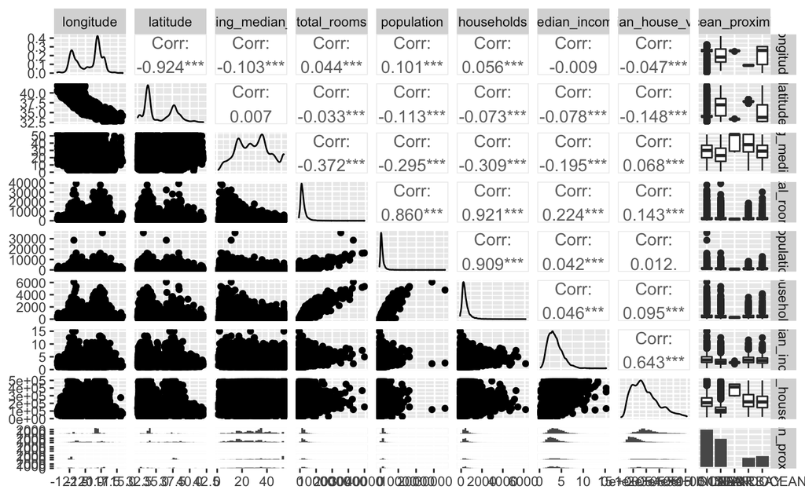

```r
ggpairs(price)
```

2. Perform further `ggplot` visualisations of any significant correlations you find.

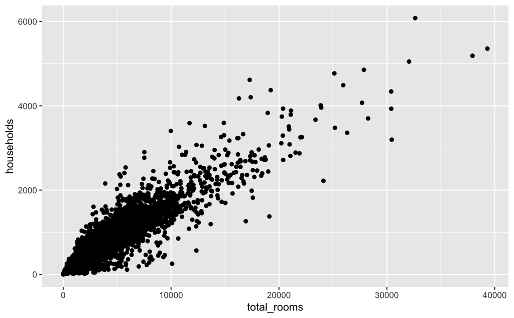

5. Shortly we may try a regression model to fit the categorical predictor `ocean_proximity`. Investigate the level of `ocean_proximity` predictors. How many dummy variables do you expect to get from it?

| ocean_proximity |
| --- |
| NEAR BAY |
| <1H OCEAN |
| INLAND |
| NEAR OCEAN |
| ISLAND |

6. Start with simple linear regression. Regress `median_house_value` on `median_income` and check the regression diagnostics.

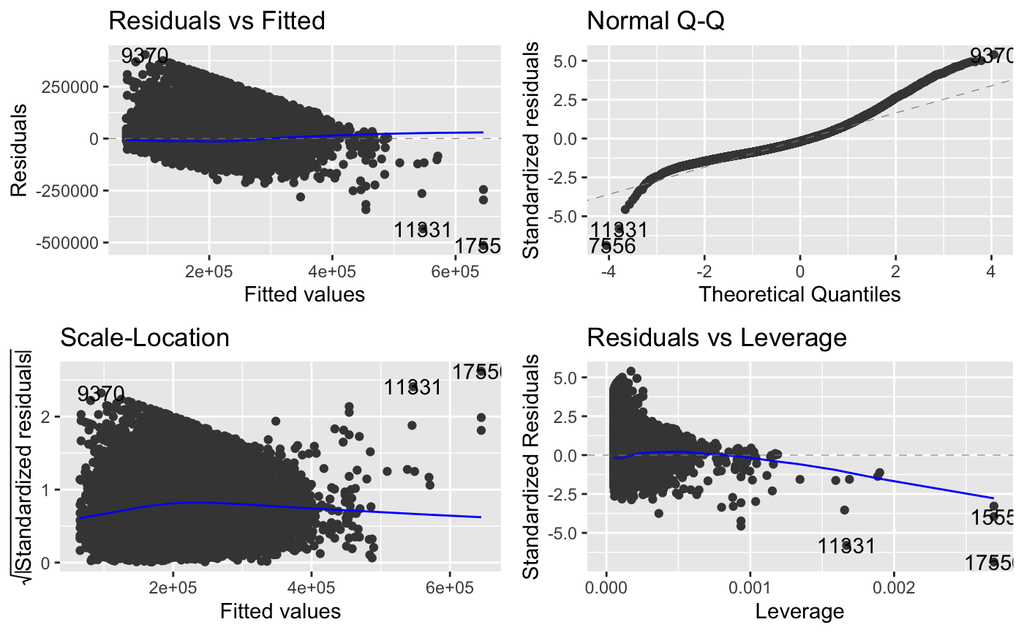

```r
model <- lm(median_house_value ~ median_income, data = price)
autoplot(model)
```

```r
summary(model)
```

```
Call:
lm(formula = median_house_value ~ median_income, data = price)

Residuals:
    Min      1Q  Median      3Q     Max
-513966  -51564  -13979   36549  403935

Coefficients:
              Estimate Std. Error t value Pr(>|t|)
(Intercept)    45457.0     1359.0   33.45   <2e-16 ***
median_income  39987.0      339.9  117.64   <2e-16 ***
---
Signif. codes:  0 ‘***’ 0.001 ‘**’ 0.01 ‘*’ 0.05 ‘.’ 0.1 ‘ ’ 1

Residual standard error: 74870 on 19673 degrees of freedom
Multiple R-squared:  0.4129,    Adjusted R-squared:  0.4129
F-statistic: 1.384e+04 on 1 and 19673 DF,  p-value: < 2.2e-16
```

residuals vs fitted, the points are bit too crowed but the line is almost the same as line 0, so it’s okay, normal q-q, bit off scale-location, accpetable

7. Add another predictor of your choice. Check your assumptions, diagnostics, and interpret the model.

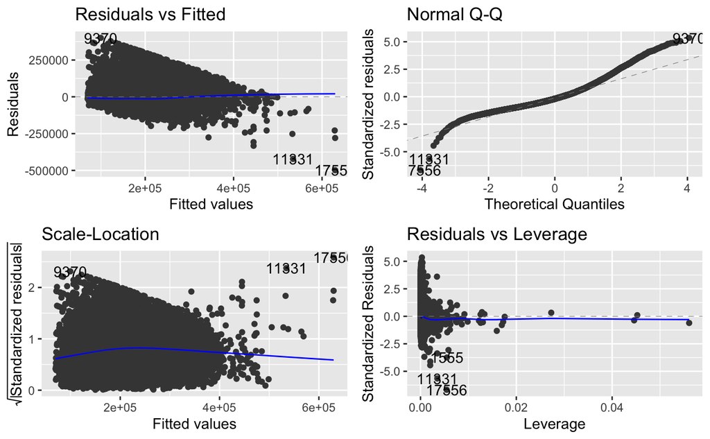

```r
model_2 <- lm(median_house_value ~ median_income * total_rooms, data = price)
autoplot(model_2)
```

```r
summary(model_2)
```

```
Call:
lm(formula = median_house_value ~ median_income * total_rooms,
    data = price)

Residuals:
    Min      1Q  Median      3Q     Max
-498488  -51439  -14173   36194  400512

Coefficients:
                            Estimate Std. Error t value Pr(>|t|)
(Intercept)               52245.2308  2098.9825  24.891  < 2e-16 ***
median_income             38405.9386   507.8802  75.620  < 2e-16 ***
total_rooms                  -2.8776     0.7025  -4.097 4.21e-05 ***
median_income:total_rooms     0.6311     0.1461   4.319 1.58e-05 ***
---
Signif. codes:  0 ‘***’ 0.001 ‘**’ 0.01 ‘*’ 0.05 ‘.’ 0.1 ‘ ’ 1

Residual standard error: 74840 on 19671 degrees of freedom
Multiple R-squared:  0.4135,    Adjusted R-squared:  0.4134
F-statistic:  4623 on 3 and 19671 DF,  p-value: < 2.2e-16
```

residual standard error dropped comparing to model 1 r squared is slightly higher, diagnostics looks very similar to each other